# Temperatura JP x CG

```r
climas = read_csv(here::here("data/clima_cg_jp-semanal.csv"),
                  col_types = "cTdddddd")

glimpse(climas)
```

```
## Observations: 2,748
## Variables: 8
## $ cidade <chr> "Campina Grande", "Campina Grande", "Campina Grande", "Ca…
## $ semana <dttm> 1992-12-27, 1993-01-03, 1993-01-10, 1993-01-31, 1993-02-…
## $ tmedia <dbl> 26.13333, 26.11905, 25.76667, 25.74000, 26.31429, 26.2857…
## $ tmax   <dbl> 30.4, 32.4, 32.2, 32.0, 32.7, 32.7, 32.3, 32.3, 32.1, 31.…
## $ tmin   <dbl> 20.7, 19.3, 19.7, 19.9, 19.6, 20.0, 20.4, 21.2, 19.0, 19.…
## $ chuva  <dbl> 0.0, 0.0, 0.0, 0.4, 0.3, 0.0, 4.9, 0.0, 0.0, 6.1, 0.4, 1.…
## $ mes    <dbl> 12, 1, 1, 1, 2, 2, 2, 2, 10, 11, 11, 11, 11, 12, 12, 12, …
## $ ano    <dbl> 1992, 1993, 1993, 1993, 1993, 1993, 1993, 1993, 1993, 199…
```

## Temperatura

### Onde é mais quente?

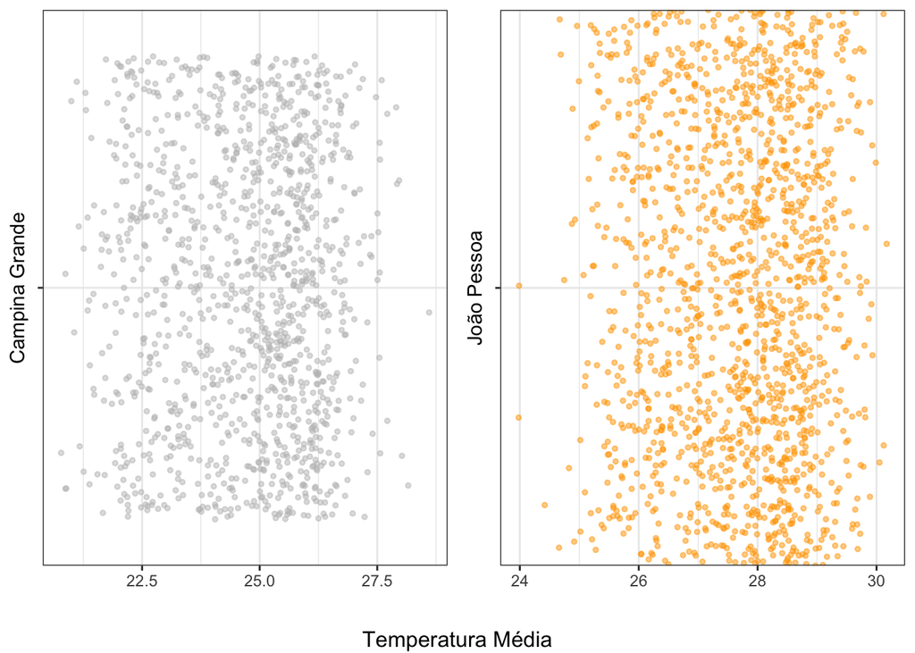

```r
cg = climas %>%
    filter(cidade == "Campina Grande")

jp = climas %>%
    filter(cidade == "João Pessoa")

cg_plots = cg %>%
    ggplot(aes(x = "", y = tmedia)) +
    labs(x="Campina Grande", y="") +
    geom_jitter(
        width = .5,
        alpha = .5,
        size = 1,
        height = 0.1,
        color = "grey"
    )+
    coord_flip()

jp_plots = jp %>%
    ggplot(aes(x="", y = tmedia)) +
    labs(x="João Pessoa", y="") +
    geom_jitter(
        width = .8,
        alpha = .5,
        size = 1,
        height = 0.1,
        color = "orange"
    )+
    coord_flip()

grid.arrange(cg_plots, jp_plots, ncol = 2, bottom="Temperatura Média")
```

Inicialmente foi efetuada uma visualizãção geral dos dados distribuidos sobre a média. É possivel observar uma concentração dos pontos sobre entre 25 e 26 graus para a cidade de Campina Grande e entre 27 e 29 graus para cidade de João Pessoa.

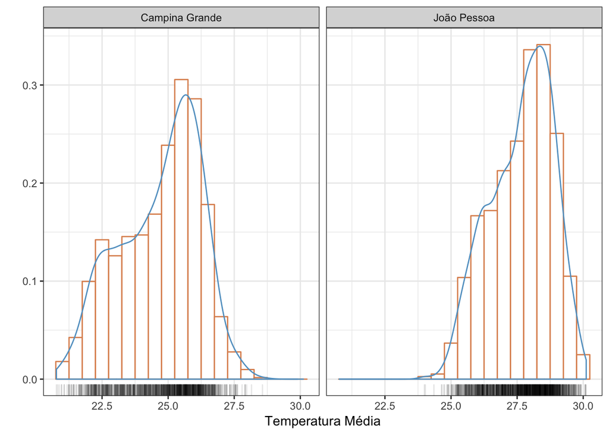

```r
climas %>%
    ggplot(aes(x = tmedia)) +
    geom_histogram(aes(y =..density..), binwidth = 0.5, color = "#de8f5d", fill = "white") +
    labs(x="Temperatura Média", y="") +
    geom_rug(alpha = .1) +
    geom_density(colour="#62A0CA") +
    facet_wrap(~ cidade)
```

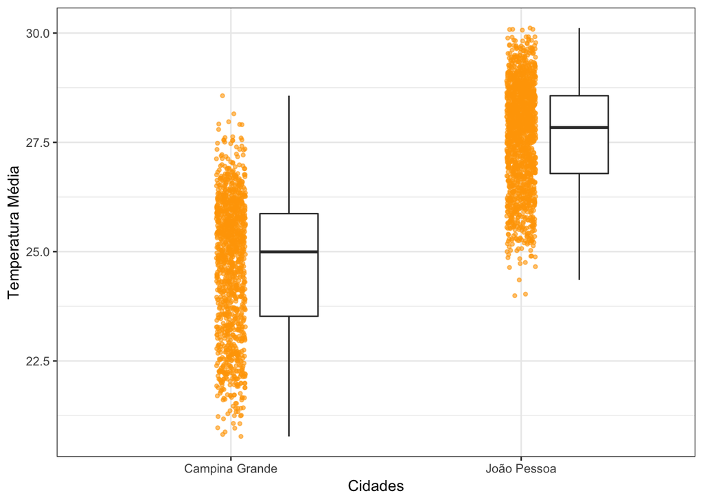

```r
climas %>%
    ggplot(aes(x = cidade, y = tmedia)) +
    geom_boxplot(
        width = .2,
        position = position_nudge(.2),
        outlier.colour = NA) +
    labs(x="Cidades", y="Temperatura Média") +
    geom_jitter(
        width = .05,
        alpha = .6,
        size = 1,
        color = "orange"
    )
```

A distribuição acima nos permite uma melhor visualização da distribuição dos pontos apresentados. É possivel observar o quão dispersos estão os pontos sob a escala da temperatura. Por fim João Pessoa aparece com temperatura média mais elevada que Campina Grande por 3 graus aproximadamente.

### Qual foi o São João mais frio de CG que está nos nossos dados?

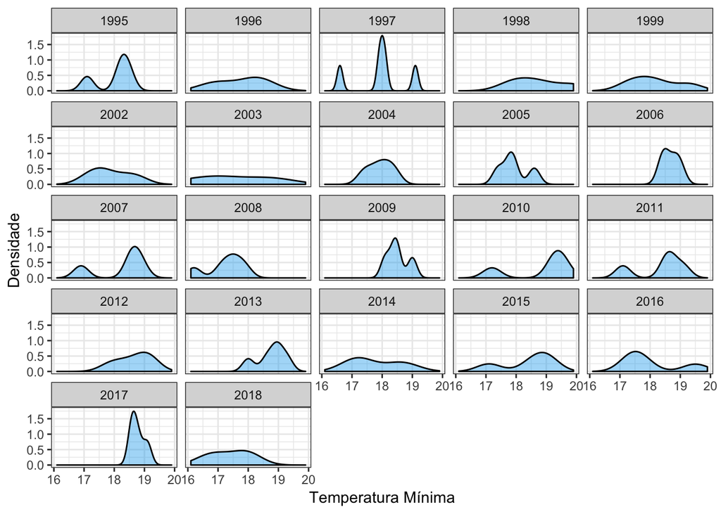

```r
cg %>%
    filter(ano >= 1992 & mes == 6) %>%
    ggplot(aes(x = tmin)) +
    geom_density(alpha = .4, fill = "#00A6ED") +
    labs(x="Temperatura Mínima", y="Densidade") +
    facet_wrap(~ ano)
```

Através do gráfico de densidade é possivel perceber padrões de densidade de temperaturas minimas ao longo dos anos. Aparentemente a mínima mais expressiva aparece no ano de 2003.

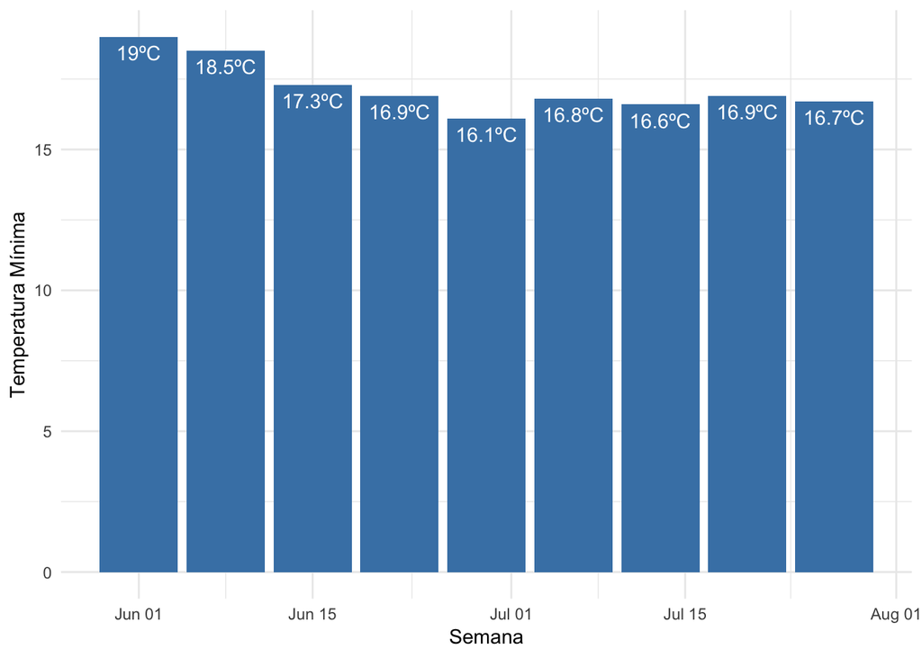

```r
cg %>%
    filter(ano == 2003 & mes >= 6 & mes <=7) %>%
    ggplot(aes(x=semana, y=tmin)) +
    geom_bar(stat="identity", fill="steelblue")+
    labs(x="Semana", y="Temperatura Mínima")+
    geom_text(aes(label=paste0(tmin,"ºC")), vjust=1.6, color="white")+
    theme_minimal()
```

O histograma acima apresenta uma visão mais granular da temperatura minima entre os meses de junho e julho de 2003. Como forma de inspecionar por quanto tempo a temperatura se mantém minima e eliminando a possibilidade de a temperatura minima mais expressiva ser apenas um ponto isolado, o intervalo foi definido com um mês a mais, onde é possivel observar que a temperatura se praticamente a mesma com pequenas variações.

## Chuva

### Quanto chove por semana em JP e CG?

Como é a distribuição do volume de chuvas por semana em JP e CG? A chuva varia mais ou menos que a temperatura? O formato da distribuição é igual?

### No geral, onde chove mais?

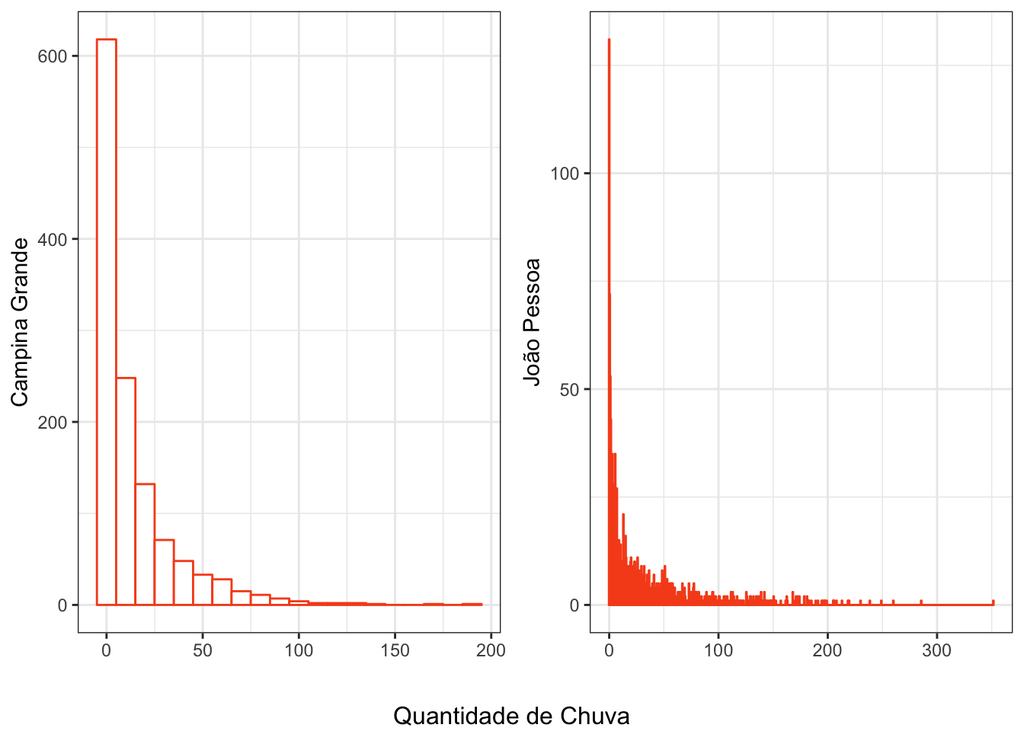

```r
cg = climas %>%
    filter(cidade == "Campina Grande")

jp = climas %>%
    filter(cidade == "João Pessoa")

hist_chuvas_cg = cg %>%
    ggplot(aes(x = chuva)) +
    labs(x="", y="Campina Grande")+
    geom_histogram(binwidth = 10, color = "#F6511D", fill = "white")

hist_chuvas_jp = jp %>%
    ggplot(aes(x = chuva)) +
    labs(x="", y="João Pessoa")+
    geom_histogram(binwidth = .5, color = "#F6511D", fill = "white")

grid.arrange(hist_chuvas_cg, hist_chuvas_jp, ncol = 2, bottom="Quantidade de Chuva")
```

Apesar de ambas as distribuições de quantidade de chuvas semanais serem assimétricas com uma grande cauda a direita, é possível observar que João Pessoa tem um volume muito superior de chuvas.

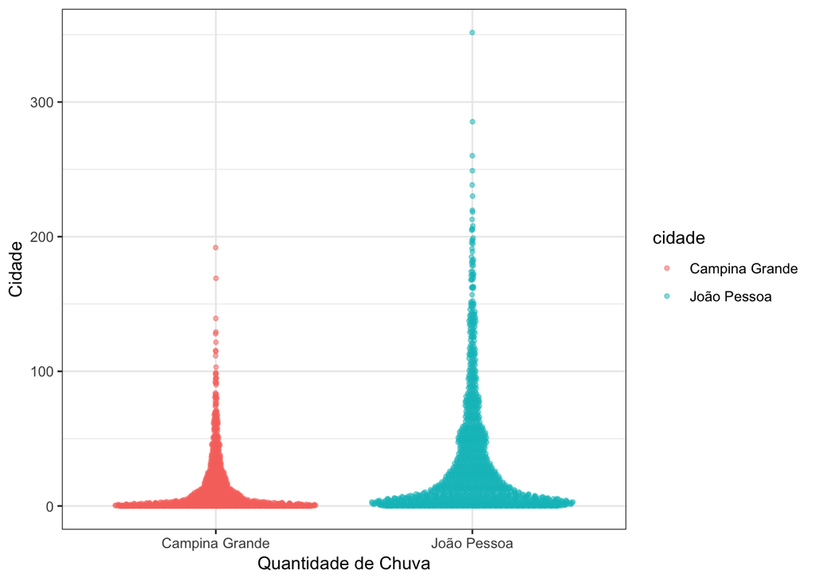

```r
climas %>%
    ggplot(aes(x = cidade, y = chuva, color = cidade)) +
    labs(x="Quantidade de Chuva", y="Cidade")+
    geom_quasirandom(alpha = .5, size = 1)
```

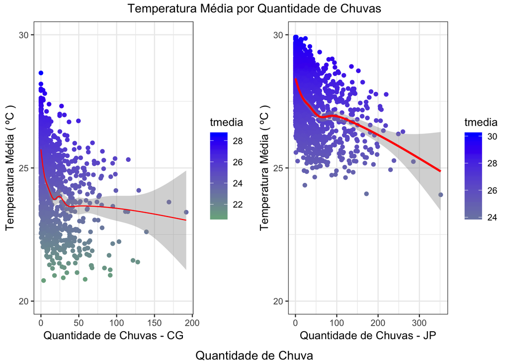

```r
cg = climas %>%
    filter(!is.na(chuva))%>%
    filter(cidade == "Campina Grande")

jp = climas %>%
    filter(!is.na(chuva))%>%
    filter(cidade == "João Pessoa")

vol_chuvas_jp = jp %>%
    ggplot(aes(x = chuva, y = tmedia)) +
    geom_point(aes(colour = tmedia)) +
    scale_colour_gradient2(low = "yellow", mid = "green" , high = "blue", midpoint = 16) +
    geom_smooth(color = "red",size = 1) +
    scale_y_continuous(limits = c(20,30), breaks = seq(5,30,5)) +
    xlab("Quantidade de Chuvas - JP") +  ylab ("Temperatura Média ( ºC )")

vol_chuvas_cg = cg %>%
    ggplot(aes(x = chuva, y = tmedia)) +
    geom_point(aes(colour = tmedia)) +
    scale_colour_gradient2(low = "yellow", mid = "green" , high = "blue", midpoint = 16) +
    geom_smooth(color = "red",size = .5) +
    scale_y_continuous(limits = c(20,30), breaks = seq(5,30,5)) +
    xlab("Quantidade de Chuvas - CG") +  ylab ("Temperatura Média ( ºC )")

grid.arrange(vol_chuvas_cg, vol_chuvas_jp, ncol = 2, top="Temperatura Média por Quantidade de Chuvas", bottom="Quantidade de Chuva")
```

A distribuição apresenta o volume de chuvas em função da temperatura. É possível observar que a temperatura é influenciada pelo aumento do volume de chuvas. A linha traçada apresenta a média dessa variabilidade em função dos dados, alem disso a área sombreada denota o intervalo de previsibilidade da temperatura em função do volume de chuvas para mais ou para menos. Por fim quanto mais elevada a temperatura para uma cidade, mais é acentuada a queda de temperatura com o aumento do volume de chuvas.

### A distribuição é diferente em meses específicos?

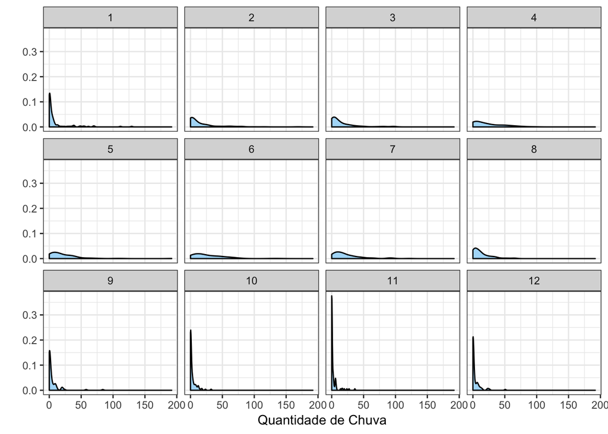

```r
cg %>%
    filter(ano >= 1992) %>%
    ggplot(aes(x = chuva)) +
    geom_density(alpha = .4, fill = "#00A6ED") +
    labs(x="Quantidade de Chuva", y="")+
    facet_wrap(~ mes)
```

Em um apanhado da quantidade de chuvas em Campina Grande é possível observar que a distribuição apresenta diferenças em meses específicos, que se enquadram justamente com o período equivalente as estações do ano. Entre os meses de Setembro e Janeiro há pouca ou nenhuma incidência de chuvas, que são aproximadamente equivalente as estações da primavera e verão.

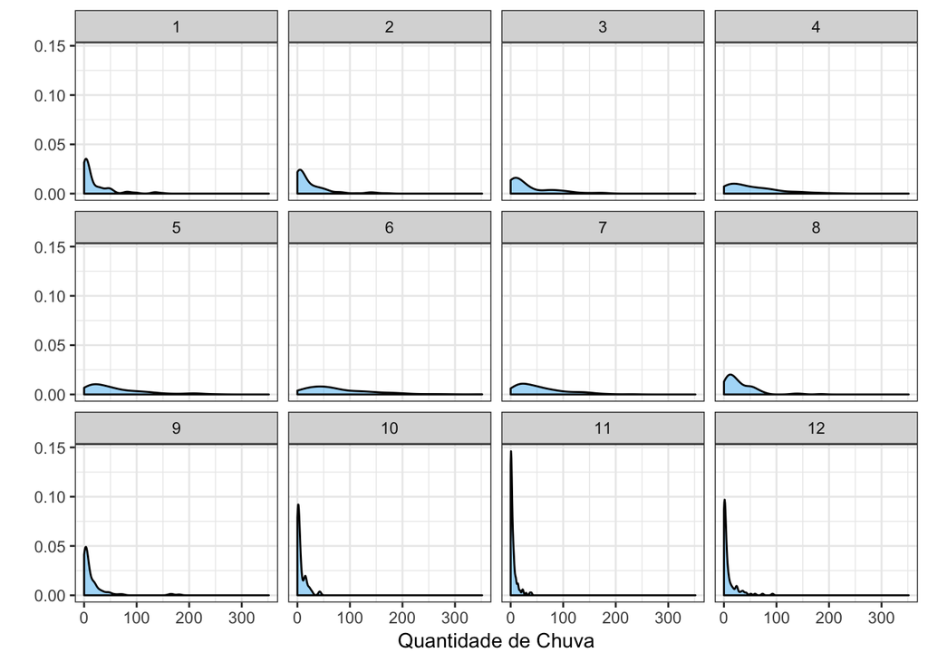

```r
jp %>%
    filter(ano >= 1992) %>%
    ggplot(aes(x = chuva)) +
    geom_density(alpha = .4, fill = "#00A6ED") +
    labs(x="Quantidade de Chuva", y="")+
    facet_wrap(~ mes)
```

Em um apanhado da quantidade de chuvas em João Pessoa é possível observar que a distribuição também apresenta diferenças em meses específicos, com períodos em que há pouca ou nenhuma incidência de chuvas.